# COVID Data

# Visualizing data

```r
us_by_state<-us%>%
  group_by(Province_State,date)%>%
  summarize(cases=sum(cases),deaths=sum(deaths),
            Population=sum(Population))%>%
  mutate(deaths_per_mill=deaths*1000000/Population)%>%
  select(Province_State,date, cases, deaths, deaths_per_mill, Population)%>%
  ungroup()
```

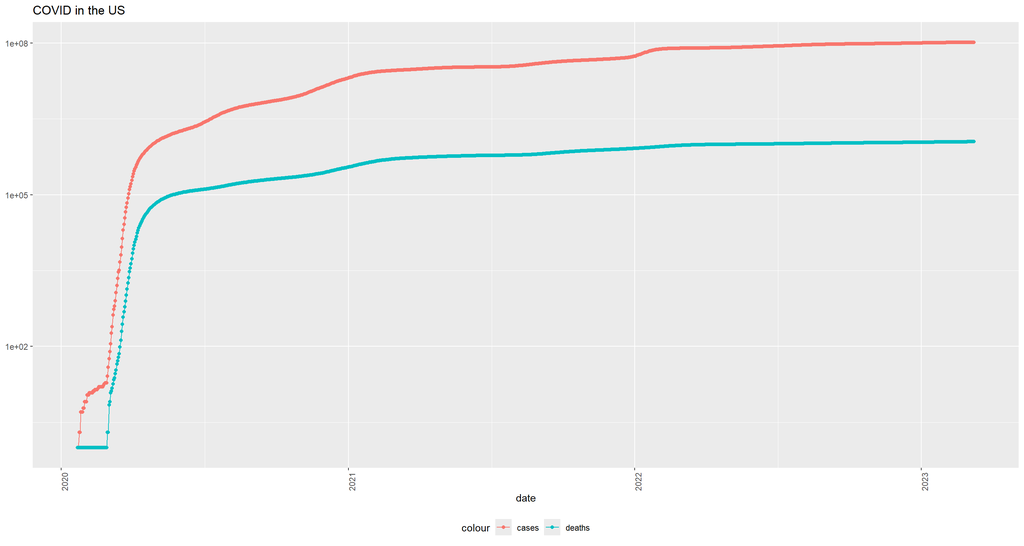

```r
us_totals<-us_by_state%>%
  group_by(date)%>%
  summarize(cases=sum(cases),deaths=sum(deaths),
            Population=sum(Population))%>%
  mutate(deaths_per_mill=deaths*1000000/Population)%>%
  select(date,cases,deaths,deaths_per_mill,Population)%>%
  ungroup()
# plot us cases and deaths over time on a log scale
us_totals%>%
  filter(cases>0)%>%
  ggplot(aes(x=date, y=cases))+
  geom_line(aes(color="cases"))+
  geom_point(aes(color="cases"))+
  geom_line(aes(y=deaths, color="deaths"))+
  geom_point(aes(y=deaths, color="deaths"))+
  scale_y_log10()+
  theme(legend.position = "bottom",
        axis.text.x=element_text(angle=90))+
  labs(title="COVID in the US",y=NULL)
```

```r
global_by_country<-global%>%
  group_by(Country.Region,date)%>%
  summarize(cases=sum(cases),deaths=sum(deaths),
            Population=sum(Population))%>%
  mutate(deaths_per_mill=deaths*1000000/Population)%>%
  select(Country.Region,date, cases, deaths, deaths_per_mill, Population)%>%
  ungroup()
```

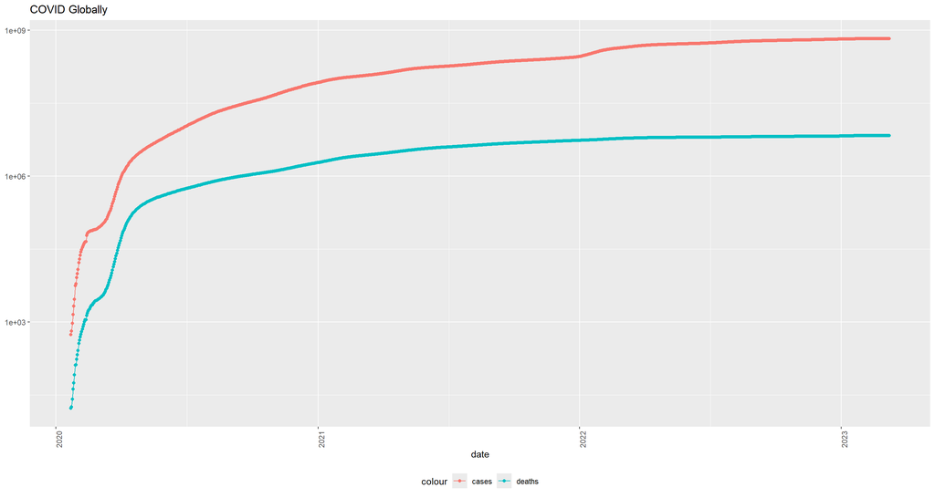

```r
global_totals<-global_by_country%>%
  group_by(date)%>%
  summarize(cases=sum(cases),deaths=sum(deaths),
            Population=sum(Population))%>%
  mutate(deaths_per_mill=deaths*1000000/Population)%>%
  select(date,cases,deaths,deaths_per_mill,Population)%>%
  ungroup()

 # plot global cases and deaths over time on a log scale
global_totals%>%
  filter(cases>0)%>%
  ggplot(aes(x=date, y=cases))+
  geom_line(aes(color="cases"))+
  geom_point(aes(color="cases"))+
  geom_line(aes(y=deaths, color="deaths"))+
  geom_point(aes(y=deaths, color="deaths"))+
  scale_y_log10()+
  theme(legend.position = "bottom",
        axis.text.x=element_text(angle=90))+
  labs(title="COVID Globally",y=NULL)
```

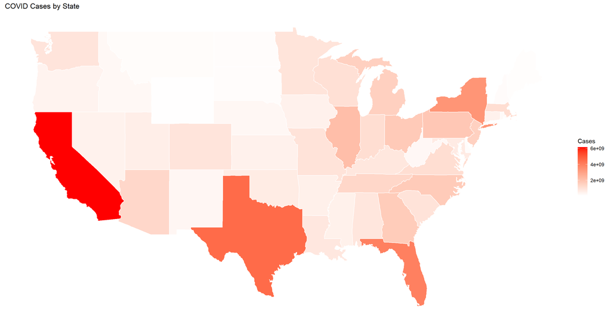

```r
# maps
#US map
us_by_state_only<-us_by_state%>%
  group_by(Province_State)%>%
  summarize(cases=sum(cases),deaths=sum(deaths),
            Population=sum(Population))%>%
  mutate(Province_State = tolower(Province_State))%>%
  ungroup()

us_states <- map_data("state") %>%
  mutate(region = tolower(region))
map_data <- us_states %>%
  left_join(us_by_state_only, by = c("region" = "Province_State"))


#check state names for any discrepancy
distinct_statenames<-us_by_state_only%>%
  distinct(Province_State)
distinct_statenames<-us_states%>%
  distinct(region)

# Plot the map of the contiguous US
#cases
ggplot(map_data, aes(long, lat, group = group, fill = cases)) +
  geom_polygon(color = "white") +
  scale_fill_gradient(low = "white", high = "red", na.value = "grey50", name = "Cases") +
  coord_fixed(1.3) +
  theme_minimal() +
  labs(title = paste("COVID Cases by State"),
       x = NULL, y = NULL) +
  theme(axis.text = element_blank(),
        axis.ticks = element_blank(),
        panel.grid = element_blank())
```

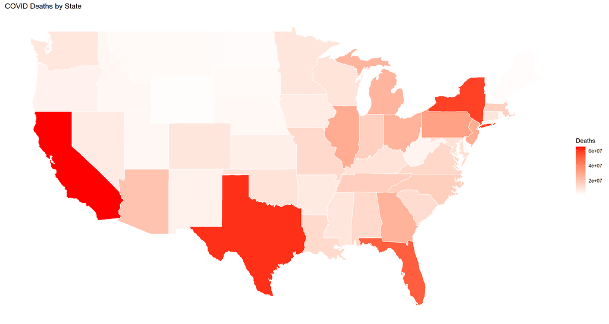

```r
#deaths
ggplot(map_data, aes(long, lat, group = group, fill = deaths)) +
  geom_polygon(color = "white") +
  scale_fill_gradient(low = "white", high = "red", na.value = "grey50", name = "Deaths") +
  coord_fixed(1.3) +
  theme_minimal() +
  labs(title = paste("COVID Deaths by State"),
       x = NULL, y = NULL) +
  theme(axis.text = element_blank(),
        axis.ticks = element_blank(),
        panel.grid = element_blank())
```

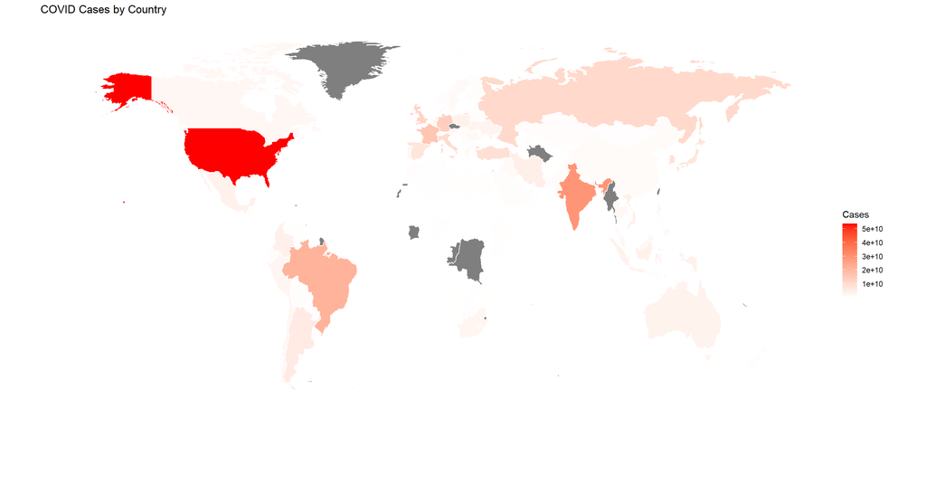

```r
#global map
global_by_country_only<-global_by_country%>%
  group_by(Country.Region)%>%
  summarize(cases=sum(cases),deaths=sum(deaths),
            Population=sum(Population))%>%
  ungroup()

global_map <- map_data("world")
global_map<-global_map%>%mutate(region = case_when(
    region == "USA" ~ "US",
    region == "UK" ~ "United Kingdom",
    region == "South Korea" ~ "Korea, South",
    region == "North Korea" ~ "Korea, North",
    TRUE ~ region
  ))
map_data <- global_map %>%
  left_join(global_by_country_only, by = c("region" = "Country.Region"))
distinct_country<-map_data%>%
  distinct(region)
distinct_country<-global_by_country_only%>%
  distinct(Country.Region)

# Plot world map
#cases
ggplot(map_data, aes(long, lat, group = group, fill = cases)) +
  geom_polygon(color = "white") +
  scale_fill_gradient(low = "white", high = "red", na.value = "grey50", name = "Cases") +
  coord_fixed(1.3) +
  theme_minimal() +
  labs(title = paste("COVID Cases by Country"),
       x = NULL, y = NULL) +
  theme(axis.text = element_blank(),
        axis.ticks = element_blank(),
        panel.grid = element_blank())
```

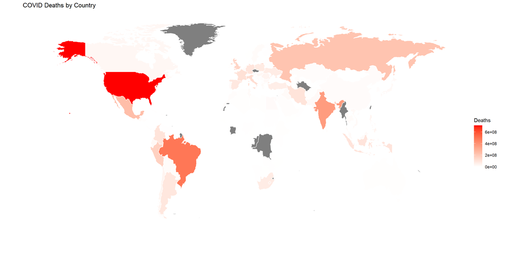

```r
#deaths
ggplot(map_data, aes(long, lat, group = group, fill = deaths)) +
  geom_polygon(color = "white") +
  scale_fill_gradient(low = "white", high = "red", na.value = "grey50", name = "Deaths") +
  coord_fixed(1.3) +
  theme_minimal() +
  labs(title = paste("COVID Deaths by Country"),
       x = NULL, y = NULL) +
  theme(axis.text = element_blank(),
        axis.ticks = element_blank(),
        panel.grid = element_blank())
```

# Analyzing and Modeling data

```r
#model US

model_US_cases <- lm(log(cases + 1) ~  Population + year(date), data = us_by_state)
model_us_deaths <- lm(log(deaths + 1) ~  Population + year(date), data = us_by_state)
summary(model_US_cases)
```

```
##
## Call:
## lm(formula = log(cases + 1) ~ Population + year(date), data = us_by_state)
##
## Residuals:
##      Min       1Q   Median       3Q      Max
## -10.7939  -0.4468   0.7360   1.3077   3.1551
##
## Coefficients:
##               Estimate Std. Error t value Pr(>|t|)
## (Intercept) -3.165e+03  1.969e+01  -160.7   <2e-16 ***
## Population   1.840e-07  1.241e-09   148.2   <2e-16 ***
## year(date)   1.571e+00  9.742e-03   161.3   <2e-16 ***
## ---
## Signif. codes:  0 '***' 0.001 '**' 0.01 '*' 0.05 '.' 0.1 ' ' 1
##
## Residual standard error: 2.221 on 63261 degrees of freedom
## Multiple R-squared:  0.4315, Adjusted R-squared:  0.4315
## F-statistic: 2.401e+04 on 2 and 63261 DF,  p-value: < 2.2e-16
```

```r
summary(model_us_deaths)
```

```
##
## Call:
## lm(formula = log(deaths + 1) ~ Population + year(date), data = us_by_state)
##
## Residuals:
##      Min       1Q   Median       3Q      Max
## -10.7734  -0.4860   0.7176   1.3143   2.9163
##
## Coefficients:
##               Estimate Std. Error t value Pr(>|t|)
## (Intercept) -2.320e+03  1.851e+01  -125.4   <2e-16 ***
## Population   1.906e-07  1.167e-09   163.4   <2e-16 ***
## year(date)   1.151e+00  9.158e-03   125.7   <2e-16 ***
## ---
## Signif. codes:  0 '***' 0.001 '**' 0.01 '*' 0.05 '.' 0.1 ' ' 1
##
## Residual standard error: 2.088 on 63261 degrees of freedom
## Multiple R-squared:  0.4019, Adjusted R-squared:  0.4019
## F-statistic: 2.126e+04 on 2 and 63261 DF,  p-value: < 2.2e-16
```

```r
#model the 4 driving states
driving_states<-us_by_state%>%
  filter(Province_State %in% c( "Texas","Florida", "New York","California"))
driving_states$Province_State <- factor(driving_states$Province_State)

model_state_cases <- lm(log(cases + 1) ~  Population + year(date), data = driving_states)
model_state_deaths <- lm(log(deaths + 1) ~  Population + year(date), data = driving_states)

summary(model_state_cases)
```

```
##
## Call:
## lm(formula = log(cases + 1) ~ Population + year(date), data = driving_states)
##
## Residuals:
##      Min       1Q   Median       3Q      Max
## -10.5377  -0.1696   0.3491   0.8863   1.9989
##
## Coefficients:
##               Estimate Std. Error t value Pr(>|t|)
## (Intercept) -3.354e+03  5.560e+01  -60.32   <2e-16 ***
## Population   5.572e-08  3.111e-09   17.91   <2e-16 ***
## year(date)   1.666e+00  2.751e-02   60.55   <2e-16 ***
## ---
## Signif. codes:  0 '***' 0.001 '**' 0.01 '*' 0.05 '.' 0.1 ' ' 1
##
## Residual standard error: 1.666 on 4441 degrees of freedom
## Multiple R-squared:  0.4789, Adjusted R-squared:  0.4787
## F-statistic:  2041 on 2 and 4441 DF,  p-value: < 2.2e-16
```

```r
summary(model_state_deaths)
```

```
##
## Call:
## lm(formula = log(deaths + 1) ~ Population + year(date), data = driving_states)
##
## Residuals:
##     Min      1Q  Median      3Q     Max
## -8.8554 -0.2273  0.1491  0.7605  1.9318
##
## Coefficients:
##               Estimate Std. Error t value Pr(>|t|)
## (Intercept) -2.494e+03  5.262e+01  -47.39   <2e-16 ***
## Population   3.151e-08  2.945e-09   10.70   <2e-16 ***
## year(date)   1.239e+00  2.604e-02   47.57   <2e-16 ***
## ---
## Signif. codes:  0 '***' 0.001 '**' 0.01 '*' 0.05 '.' 0.1 ' ' 1
##
## Residual standard error: 1.577 on 4441 degrees of freedom
## Multiple R-squared:  0.3529, Adjusted R-squared:  0.3526
## F-statistic:  1211 on 2 and 4441 DF,  p-value: < 2.2e-16
```

```r
#model 6 countries similar in age structure to the US
similar_countries<-global_by_country%>%
  filter(Country.Region %in% c("Canada", "Germany", "Australia", "United Kingdom", "France","Japan"))

model_country_cases <- lm(log(cases + 1) ~  Population + year(date), data = similar_countries)
model_country_deaths <- lm(log(deaths + 1) ~  Population + year(date), data = similar_countries)

summary(model_country_cases)
```

```
##
## Call:
## lm(formula = log(cases + 1) ~ Population + year(date), data = similar_countries)
##
## Residuals:
##      Min       1Q   Median       3Q      Max
## -10.6630  -1.1214   0.5533   1.4744   4.1339
##
## Coefficients:
##               Estimate Std. Error t value Pr(>|t|)
## (Intercept) -5.610e+03  6.646e+01  -84.41   <2e-16 ***
## Population   1.488e-08  9.227e-10   16.12   <2e-16 ***
## year(date)   2.782e+00  3.288e-02   84.60   <2e-16 ***
## ---
## Signif. codes:  0 '***' 0.001 '**' 0.01 '*' 0.05 '.' 0.1 ' ' 1
##
## Residual standard error: 2.288 on 5743 degrees of freedom
##   (1092 observations deleted due to missingness)
## Multiple R-squared:  0.5652, Adjusted R-squared:  0.5651
## F-statistic:  3733 on 2 and 5743 DF,  p-value: < 2.2e-16
```

```r
summary(model_country_deaths)
```

```
##
## Call:
## lm(formula = log(deaths + 1) ~ Population + year(date), data = similar_countries)
##
## Residuals:
##     Min      1Q  Median      3Q     Max
## -8.4948 -1.4310  0.5583  1.8798  3.8687
##
## Coefficients:
##               Estimate Std. Error t value Pr(>|t|)
## (Intercept) -3.470e+03  6.943e+01  -49.97   <2e-16 ***
## Population   1.551e-08  9.639e-10   16.09   <2e-16 ***
## year(date)   1.721e+00  3.435e-02   50.09   <2e-16 ***
## ---
## Signif. codes:  0 '***' 0.001 '**' 0.01 '*' 0.05 '.' 0.1 ' ' 1
##
## Residual standard error: 2.39 on 5743 degrees of freedom
##   (1092 observations deleted due to missingness)
## Multiple R-squared:  0.3275, Adjusted R-squared:  0.3273
## F-statistic:  1399 on 2 and 5743 DF,  p-value: < 2.2e-16
```

# Conclusion

Given the data set it appears that COVID cases and death most severely affected the US. Texas, Florida, New York, and California are the states that were most affected in the US. There are several reasons this could be true such as the prevalence of the anti vaccine movement, delayed response (lockdown), and a large population.

I looked into countries with similar age structures as the US because COVID was more dangerous for older individuals. Even when looking at similar countries appears that other countries possibly handled the pandemic more effectively than the US.

To note bias in this report:

- There could be bias in the data
  - some countries/states may not have had easy access to testing resulting in lower cases than in actuality.
  - Some countries may have different medical standards for how they link deaths to being caused COVID.
  - To combat this I compared similar countries in age structures, development, and culture.
- My personal bias comes in with my own experience with COVID. The disruptions to daily life and significant challenges during this time may have influenced my perspective. To combat this I attempted to approach the data with as much objectivity as possibly